# Socio-Demographic Groups

First we need to tell R where are the data files are stored.

```r
setwd("C:/Users/laall/Desktop/GitHub/WVS_Analysis_Leigh_Allison")
```

```r
#install.packages("FactoMineR")
library("FactoMineR")

#install.packages("ltm")
library("ltm")
#install.packages("lessR")
#install.packages("devtools")
library("lessR")
library("devtools")

#install.packages("stats4")
library("stats4")

#install.packages("lattice")
library("lattice")


#install.packages("psych")
library("psych")
#install.packages("stats")
library("stats")

#install.packages('Rcpp')
library("Rcpp")

#install_github('philchalmers/mirt')
library('mirt')
#install.packages("car", repos = 'http://cran.us.r-project.org')
library(car)
```

# Analysis of National Subgroups

There is some debate as to whether as to the right approach to making national level cultural indicators. We first attempted to aggregate and then find latent dimensions. Since there was no apparent trend, we will now attempt to study a subgroup within a nation. Based on previous studies of culture, gender, age, education, and socio-economic class has been known to affect people’s cultural views. We will therefore divide people into these groups and then aggregate by nation to determine if there are any latent cultural dimensions visible when you control for gender, age, education, socio-economic class, and we have added town size as an indication of rural or urban.

To do this, we must have a data frame which includes all the quesiton variables with the exception of those that we have due to missingness at the national level.

## Invidiual Data: Cleaning

```r
Updated_Categorical_data <- read.csv("Updated_Categorical_Data.csv")
Updated_Ordinal_data <- read.csv("Updated_Ordinal_Data.csv")

Individual_Data <- merge(Updated_Categorical_data, Updated_Ordinal_data, by.x = "X", by.y = "X")

#Similar to the aggregate data we want to change the responses that are don't know, missing, or were to asked to NA
RecodetoNA<- function(QuestionColName){
  QuestionColName<- recode(QuestionColName, "c(-1,-2,-6) = NA")
}
Individual_Data  <- as.data.frame(apply(Individual_Data ,2,RecodetoNA))
```

# Socio Demongraphic Data

We stored the SD variables in a separate data frame from the survey questions. We need to load that data into the program in order to analyze it.

```r
SD_data       <- read.csv("SD_Raw_Data.csv")
SD_Categorical_Data <- read.csv("SD_Categorical_subset.csv")
SD_Ordinal_Data <- read.csv("SD_Ordinal_subset.csv")
```

## Age

Respondants were asked their age. They interviewer recoded the response in years. In order to have less options, we grouped people in 5 year increments.

```r
SD_FreeResponse <- read.csv("FR_subset.csv")
Age_Cat <- 0
SD_FreeResponse <- cbind(SD_FreeResponse, Age_Cat)

SD_FreeResponse$Age_Cat[SD_FreeResponse$V242 <= 20] <- "Under20"
SD_FreeResponse$Age_Cat[SD_FreeResponse$V242 > 20 & SD_FreeResponse$V242 <= 24] <- "20-24"
SD_FreeResponse$Age_Cat[SD_FreeResponse$V242 > 24 & SD_FreeResponse$V242 <= 29] <- "25-29"
SD_FreeResponse$Age_Cat[SD_FreeResponse$V242 > 29 & SD_FreeResponse$V242 <= 34] <- "30-34"
SD_FreeResponse$Age_Cat[SD_FreeResponse$V242 > 34 & SD_FreeResponse$V242 <= 39] <- "35-39"
SD_FreeResponse$Age_Cat[SD_FreeResponse$V242 > 39 & SD_FreeResponse$V242 <= 44] <- "40-44"
SD_FreeResponse$Age_Cat[SD_FreeResponse$V242 > 44 & SD_FreeResponse$V242 <= 49] <- "45-49"
SD_FreeResponse$Age_Cat[SD_FreeResponse$V242 > 49 & SD_FreeResponse$V242 <= 54] <- "50-54"
SD_FreeResponse$Age_Cat[SD_FreeResponse$V242 > 54 & SD_FreeResponse$V242 <= 59] <- "55-59"
SD_FreeResponse$Age_Cat[SD_FreeResponse$V242 > 59 & SD_FreeResponse$V242 <= 64] <- "60-64"
SD_FreeResponse$Age_Cat[SD_FreeResponse$V242 > 64 & SD_FreeResponse$V242 <= 69] <- "65-69"
SD_FreeResponse$Age_Cat[SD_FreeResponse$V242 > 69 & SD_FreeResponse$V242 <= 74] <- "70-74"
SD_FreeResponse$Age_Cat[SD_FreeResponse$V242 > 74 & SD_FreeResponse$V242 <= 80] <- "75-80"
```

Socio-demographic variables have been kept separate of question variables because they are characteristics of the person not their values.

```r
#238 - Economic Class
#240 - Gender
#242 - Age (numeric)
#248 - Education
#253 - Town Size

Individual_Data_SD<- merge(SD_Categorical_Data[,c("X","V238", "V240", "V248", "V253"), ],Individual_Data,
                           by.x = "X", by.y = "X")

PFL_5Ordinal_Data <- read.csv("PFL_5Ordinal_subset.csv")
#V161,V162,V163 were not in the Updated Ordinal List because they are on the a 5 pt scale instead of 10.
Individual_Data_SD<- merge(PFL_5Ordinal_Data,Individual_Data_SD,
                           by.x = "X", by.y = "X")

Individual_Data_SD <- cbind(Individual_Data_SD, SD_FreeResponse$Age_Cat, SD_FreeResponse$V242)
```

Using the aggregate analysis finding, we remove the same questions from the individual dataframe that we did from the aggregate data based on the sensitivity analysis.

```r
#Questions to Remove based on national sensitivity analysis.

#Due to high precentages of AdminNA remove questions: V74B,V90,V91,V92,V93,V94,v160A,160B,v160C
#v160D,v160E,v160F,v160G,v160H,v160I,v160J,V217_ESMA,V218_ESMA,V224_ESMA,V220_ESMA,V221_ESMA,V222_ESMA,V228A,
#V228B,V228C,V228D,V228E,V228F,V228G,V228H,V228I,V228J,V228K,V243_AU,V244_AU,V56_NZ,V203A,V207A

#Due to high precentages of Missing remove questions - none

#Due to high precentages of Don'tKnow remove questions: V133,V140,V193,V152

#Questions 144 (religion), 215 (political organizations - 18 variables), 247 (language) were removed beause they had to many categories.
#219_ESMA was removed because it was not answered by any of the 60 countries.
#228 and 228_2 were removed because they are related to political parties in specific countries

#Make one DF with all the single question dataframes to remove

Cleaned_Individual_Data_SD<- Individual_Data_SD[,-which(names(Individual_Data_SD) %in% c(
"V144", "V247","V219_ESMA", "V228", "V228_2", "V74B","V90","V91","V92","V93","V94",
"V160A","V160B","V160C","V160D","V160E", "V160F","V160G","V160H","V160I","V160J",
"V217_ESMA","V218_ESMA","V224_ESMA","V220_ESMA","V221_ESMA","V222_ESMA",
"V228A","V228B", "V228C","V228D","V228E","V228F","V228G","V228H","V228I","V228J", "V228K",
"V243_AU","V244_AU","V56_NZ","V203A","V207A",
"V133","V140","V193","V152",
"V215_01","V215_02","V215_03","V215_04","V215_05","V215_06","V215_07",
"V215_08","V215_09","V215_10","V215_11","V215_12","V215_13","V215_14","V215_15","V215_16","V215_17","V215_18"))]

#We need to remove the countries chosen above
countries_to_remove_ind <-  c(414, 634,48,818)
Cleaned_Individual_Data_SD <- Cleaned_Individual_Data_SD[-which(Cleaned_Individual_Data_SD$V2.x %in% c(414,634,48,818)),]

#This data frame has 226 variables
write.csv(Cleaned_Individual_Data_SD, "Cleaned_Individual_Data_Raw.csv")

#if we wanted to take out the demographic data to study just the individuals we just remove the columns.
# still includes country and weight columns
#should be 219 variables
Individual_Data_Final <- Cleaned_Individual_Data_SD[,-which(names(Cleaned_Individual_Data_SD)
                                                              %in% c("V238", "V240", "V248", "V253",
                                                                     "SD_FreeResponse$V242", "SD_FreeResponse$Age_Cat",
                                                                     "V258.y"))]
#remove row counting columns
Individual_Data_Final <- Individual_Data_Final[,-c(1,5)]

Individual_Data_Final<- Individual_Data_Final[ , -which(names(Individual_Data_Final) %in%
                                                                          c("V2.y", "X.1.y"))]
IDV_ColumnNames <- colnames(Individual_Data_Final)

#for the ANOVA analysis, we'd like to keep the 240 and 248 and the 2 age related variables
#This DF has 223 variables
Individual_Data_Final_ANOVA <- Cleaned_Individual_Data_SD[,-which(names(Cleaned_Individual_Data_SD)
                                                              %in% c("V258.y", "V2.y","X.1.y", "X.1.x"))]

#To make sociodemographic groups, I'm going to start by not including age
Individual_Data_Final_noAge <- Cleaned_Individual_Data_SD[,-which(names(Cleaned_Individual_Data_SD)
                                                              %in% c("SD_FreeResponse$V242", "SD_FreeResponse$Age_Cat",
                                                                     "V258.y", "V2.y"))]

#to study just the individuals need to also take out the weight and country columns
#this df has 217 variables (and does not include the SD variables)
Individual_Data_JustVariables<- Individual_Data_Final[ , -which(names(Individual_Data_Final) %in%
                                                                          c("V258.x","V2.x", "V2.y"))]
```

## Analysis at an Invidiual Level: ANOVA

In order to understand which variables are contributing to the variance of the questions repsonses, we run ANOVA tests on the randomly selected variables. Understanding that there are demographic variables which are affecting the responses will help to more accurately aggregate the data at a national level. For those variables which significantly affect the variance of the responses, the question variable will be subdivided by the affecting variable.

The ANOVA analysis is done on question individually. Below is code to randomly select a quesiton for each iteration. The code prints the selected question title

```r
#dim(Individual_Data_Final_ANOVA)
#238 - Economic Class
#240 - Gender
#242 - Age (numeric)
#248 - Education
#253 - Town Size
column_number <- sample(1:213, 1)
colname <- colnames(Individual_Data_JustVariables)[column_number]
colname
```

```
## [1] "V207"
```

```r
question <- as.data.frame(cbind(Individual_Data_Final_ANOVA[,colname],
                                Individual_Data_Final_ANOVA$V2.x,
                                Individual_Data_Final_ANOVA$V240,
                                Individual_Data_Final_ANOVA$V248,
                                Individual_Data_Final_ANOVA$V238,
                                Individual_Data_Final_ANOVA$V253,
                 Individual_Data_Final_ANOVA$`SD_FreeResponse$Age_Cat`,
                 Individual_Data_Final_ANOVA$`SD_FreeResponse$V242`))

colnames(question)<- c("Question_Response", "Country.Code", "Gender", "Education",
                       "Economic Class","Town Size", "Age_Cat", "Age")
```

A primary premise of this analysis is that the country significantly affects respondants choices. To test this we see how much of the variance is accounted for by the country code. We will first look at a single random variable.

```r
Anova_Model_Country <- lm(question$Question_Response ~ as.factor(question$Country.Code)
                  + question$Gender + question$Age_Cat)
anova(Anova_Model_Country)
```

```
## Analysis of Variance Table
##
## Response: question$Question_Response
##                                     Df Sum Sq Mean Sq F value
## as.factor(question$Country.Code)    55  54050  982.73 222.749
## question$Gender                      1    130  129.60  29.375
## question$Age_Cat                     1    538  538.10 121.967
## Residuals                        82616 364490    4.41
##                                                 Pr(>F)
## as.factor(question$Country.Code) < 0.00000000000000022
## question$Gender                          0.00000005981
## question$Age_Cat                 < 0.00000000000000022
## Residuals
```

Now we see if education level is significantly adding to the variation in responses.

```r
Anova_Model_Education <- lm(question$Question_Response ~ as.factor(question$Education)
                  + question$Gender + question$Age_Cat)
anova(Anova_Model_Education)
```

```
## Analysis of Variance Table
##
## Response: question$Question_Response
##                                  Df Sum Sq Mean Sq F value
## as.factor(question$Education)    11   4107  373.32 74.3554
## question$Gender                   1     83   82.98 16.5264
## question$Age_Cat                  1      2    2.13  0.4241
## Residuals                     82659 415014    5.02
##                                              Pr(>F)
## as.factor(question$Education) < 0.00000000000000022
## question$Gender                          0.00004802
## question$Age_Cat                             0.5149
## Residuals
```

```r
Anova_Model_TownSize <- lm(question$Question_Response ~ as.factor(question$`Town Size`)
                  + question$Gender + as.factor(question$Age_Cat))
anova(Anova_Model_TownSize)
```

```
## Analysis of Variance Table
##
## Response: question$Question_Response
##                                    Df Sum Sq Mean Sq F value
## as.factor(question$`Town Size`)    10   2002 200.237  39.723
## question$Gender                     1    146 145.523  28.869
## as.factor(question$Age_Cat)        13    438  33.673   6.680
## Residuals                       82649 416622   5.041
##                                                Pr(>F)
## as.factor(question$`Town Size`) < 0.00000000000000022
## question$Gender                      0.00000007766326
## as.factor(question$Age_Cat)          0.00000000000057
## Residuals
```

```r
Anova_Model_EconClass <- lm(question$Question_Response ~ as.factor(question$`Economic Class`)
                  + question$Gender + as.factor(question$Age_Cat))
anova(Anova_Model_EconClass)
```

```
## Analysis of Variance Table
##
## Response: question$Question_Response
##                                         Df Sum Sq Mean Sq F value
## as.factor(question$`Economic Class`)     8   1952 244.012 48.3951
## question$Gender                          1    145 145.360 28.8294
## as.factor(question$Age_Cat)             13    377  28.986  5.7488
## Residuals                            82651 416733   5.042
##                                                     Pr(>F)
## as.factor(question$`Economic Class`) < 0.00000000000000022
## question$Gender                             0.000000079256
## as.factor(question$Age_Cat)                 0.000000000108
## Residuals
```

Now let’s look at the combined effect.

```r
Anova_Model<- lm(question$Question_Response ~ as.factor(question$Education) + as.factor(question$Country.Code)
                  + as.factor(question$`Economic Class`) + as.factor(question$`Town Size`)
                  + question$Gender + question$Age_Cat)
anova(Anova_Model)
```

```
## Analysis of Variance Table
##
## Response: question$Question_Response
##                                         Df Sum Sq Mean Sq F value
## as.factor(question$Education)           11   4107  373.32  85.300
## as.factor(question$Country.Code)        55  51695  939.90 214.757
## as.factor(question$`Economic Class`)     8    686   85.76  19.595
## as.factor(question$`Town Size`)          9    884   98.27  22.454
## question$Gender                          1     87   87.00  19.879
## question$Age_Cat                         1    298  298.32  68.163
## Residuals                            82587 361449    4.38
##                                                     Pr(>F)
## as.factor(question$Education)        < 0.00000000000000022
## as.factor(question$Country.Code)     < 0.00000000000000022
## as.factor(question$`Economic Class`) < 0.00000000000000022
## as.factor(question$`Town Size`)      < 0.00000000000000022
## question$Gender                                0.000008262
## question$Age_Cat                     < 0.00000000000000022
## Residuals
```

## Analysis at an Invidiual Level: ANOVA Results

We just ran an ANOVA for a single question, now let’s look at the results of 10 random questions. (Note that each questions is represented by a single varaible in this dataframe. The numbers are the same as those coded by the WVS and can be downloaded from their website.)

```r
#To combine multiple questions into a single dataframe

i = 0
questions = c()
Question_Anova_Model_Summary_Fvalues <- c()
Question_Anova_Model_Summary_Pvalues <- c()

for (i in 1:10){
  column_number <- sample(1:213, 1)
  colname <- colnames(Individual_Data_JustVariables)[column_number]
  colname
  questions <- c(questions,colname)
  question <- as.data.frame(cbind(Individual_Data_Final_ANOVA[,colname],
                                  Individual_Data_Final_ANOVA$V2.x,
                                  Individual_Data_Final_ANOVA$V240,
                                  Individual_Data_Final_ANOVA$V248,
                                  Individual_Data_Final_ANOVA$V238,
                                  Individual_Data_Final_ANOVA$V253,
                                  Individual_Data_Final_ANOVA$`SD_FreeResponse$Age_Cat`))

  colnames(question)<- c("Question_Response", "Country.Code", "Gender", "Education", "Economic Class","Town Size","Age_Cat")

  Anova_Model<- lm(question$Question_Response ~ as.factor(question$Education)
                  + as.factor(question$Country.Code)
                  + as.factor(question$`Economic Class`)
                  + as.factor(question$`Town Size`)
                  + question$Gender + question$Age_Cat)

  Anova_Model_Summary <- as.data.frame(anova(Anova_Model))

  Question_Anova_Model_Summary_Fvalues <- cbind(Question_Anova_Model_Summary_Fvalues,
                                        Anova_Model_Summary$`F value`)

  Question_Anova_Model_Summary_Pvalues <- cbind(Question_Anova_Model_Summary_Pvalues,
                                         Anova_Model_Summary$`Pr(>F)`)
  i = i+1
}

Question_Anova_Model_Summary_Fvalues <- t(as.data.frame(Question_Anova_Model_Summary_Fvalues))
#rownames(Question_Anova_Model_Summary_Fvalues) <- questions
#colnames(Question_Anova_Model_Summary_Fvalues) <-c("Education", "Country", "Gender",
                                                   #"Economic Class","Town Size", "Age_Cat", "Residuals")

Question_Anova_Model_Summary_Pvalues <- t(as.data.frame(Question_Anova_Model_Summary_Pvalues))
rownames(Question_Anova_Model_Summary_Pvalues) <- questions
colnames(Question_Anova_Model_Summary_Pvalues) <-c("Education", "Country", "Gender",
                                                   "Economic Class","Town Size", "Age_Cat", "Residuals")
Question_Anova_Model_Summary_Pvalues
```

```
##          Education Country       Gender Economic Class     Town Size
## V102  6.281365e-60       0 1.539817e-19   4.155846e-15  7.684707e-02
## V185 4.318264e-248       0 1.597785e-11   1.061260e-04  2.272880e-31
## V33   2.865452e-35       0 2.157575e-80   6.262529e-03  6.278413e-02
## V202  1.432235e-68       0 6.632175e-69   3.797672e-10  7.068122e-17
## V4    1.315119e-24       0 6.199633e-26   2.088217e-14  2.411278e-34
## V48   3.816578e-19       0 1.448219e-07   6.845346e-27 1.362121e-236
## V226 8.498395e-107       0 1.008290e-13   7.778003e-58  8.845582e-10
## V113  9.548374e-44       0 2.159891e-53   8.300131e-40  9.658499e-10
## V173  1.745935e-98       0 4.221484e-22   6.583933e-50  2.826229e-15
## V22  2.052949e-170       0 2.284934e-07   7.696556e-08  2.981394e-05
##                           Age_Cat Residuals
## V102 0.00001167179521213405206468        NA
## V185 0.01936071959552017329730944        NA
## V33  0.00472988850919812183620783        NA
## V202 0.00000000000000000199586271        NA
## V4   0.27996577947975981315309468        NA
## V48  0.00000016593658678876628461        NA
## V226 0.00000035403588950045218734        NA
## V113 0.00000000000000001542076360        NA
## V173 0.00000000000000000004767703        NA
## V22  0.00000000000147573990958240        NA
```

## Matched Aggregates

When Hofestede studied his data, he had a rather homogenous group. In the WVS sample, the respondants are intended to be representative of the nation in which they were sampled. Which means that diversity within the sample is similar to the diversity of the country. In order to do this for the WVS data, we need can control for the major factors - age, education, gender, socio-economic status, and town size. This makes can make for many different groups depending on how these characteristics are grouped. We then need to be able to compare the results to determine if they are showing the same results.

```r
#need to remove the respondants who do not have data in these columns
desiredCols <- c("V240", "V238", "V248", "V253")
completeFun <- function(data, desiredCols) {
  completeVec <- complete.cases(data[, desiredCols])
  return(data[completeVec, ])
}

Individual_Data_Final_noAge <- completeFun(Individual_Data_Final_noAge, desiredCols)

#Make a list of respondants who are male, unitersity educated, upper-middle class and living in a town larger than 100K

Male_University_UpperMid_City <- c()

for(aRow in c(1:nrow(Individual_Data_Final_noAge))){
  if (Individual_Data_Final_noAge[aRow, "V240"]==1 &&
      Individual_Data_Final_noAge[aRow, "V238"]==2 &&
      (Individual_Data_Final_noAge[aRow, "V248"]==8 || Individual_Data_Final_noAge[aRow, "V248"]==9)  &&
      (Individual_Data_Final_noAge[aRow, "V253"]==7 || Individual_Data_Final_noAge[aRow, "V253"]==8) ){
    Male_University_UpperMid_City <- rbind(Male_University_UpperMid_City, Individual_Data_Final_noAge[aRow,])
      }
  next
}

CountryCount <- length(unique(Male_University_UpperMid_City$V2.x))
#now we have a dataframe with just males who are university education, in the upper middle class, living in a town with a population over 100K. There are only 1277 resondants who make up this group from 40 countries. Thats 1.4% of the orginal sample size.


#from here we have to redivide the samples into ordinal and categorical and aggregate based on country.
Male_University_UpperMid_City_Categorical <- Male_University_UpperMid_City[,c(10,11,12:179)]
Male_University_UpperMid_City_Ordinal <- Male_University_UpperMid_City[,c(10,11,181:222)]
Male_University_UpperMid_City_Ordinal_5count <- Male_University_UpperMid_City[,c(10,11,2:4)]
```

```r
#Rename Weight and Country Column to match
colnames(Male_University_UpperMid_City_Categorical)[colnames(Male_University_UpperMid_City_Categorical)=="V2.x"] <- "V2"
colnames(Male_University_UpperMid_City_Categorical)[colnames(Male_University_UpperMid_City_Categorical)=="V258.x"] <- "V258"
colnames(Male_University_UpperMid_City_Ordinal)[colnames(Male_University_UpperMid_City_Ordinal)=="V2.x"] <- "V2"
colnames(Male_University_UpperMid_City_Ordinal)[colnames(Male_University_UpperMid_City_Ordinal)=="V258.x"] <- "V258"
colnames(Male_University_UpperMid_City_Ordinal_5count)[colnames(Male_University_UpperMid_City_Ordinal_5count)=="V2.x"] <- "V2"
colnames(Male_University_UpperMid_City_Ordinal_5count)[colnames(Male_University_UpperMid_City_Ordinal_5count)=="V258.x"] <- "V258"
```

# Calculations for Categorical Questions - Counting

Now the precentage of people who answered each category for each questions can be computed by nation. In this first function we are counting the number of weighted responses to each questions response. The function returns a dataframe with the number of responses for each category as a column and nations as rows. Note, the function must be used in combination with the aggregate function in order to have the rows to be nations. We show an example in question calculation before applying it to all of the WVS questions. - This is the same function as previously used.

```r
Count_Calc <- function(aColumn){
  miss=0
  r0=0
  r1=0
  r2=0
  r3=0
  r4=0
  r5=0
  r6=0
  r7=0
  r8=0
  rneg1=0
  rneg2=0
  rneg6=0

  count =1

  for (value in aColumn){
    if(is.na(value)){
      miss = miss + 1
      next
    }
    if(value == 0){
      r0 = r0 + Updated_Categorical_data$V258[count]
      next
    }

    if(value == 1){
      r1 = r1 + Updated_Categorical_data$V258[count]
      next
    }
    if(value == 2){
      r2 = r2 + Updated_Categorical_data$V258[count]
      next
    }
    if(value == 3){
      r3 = r3 + Updated_Categorical_data$V258[count]
      next
    }
    if(value == 4){
      r4 = r4 + Updated_Categorical_data$V258[count]
      next
    }
    if(value == 5){
      r5 = r5 + Updated_Categorical_data$V258[count]
      next
    }
    if(value == 6){
      r6 = r6 + Updated_Categorical_data$V258[count]
      next
    }
    if(value == 7){
      r7= r7 + Updated_Categorical_data$V258[count]
      next
    }
    if(value == 8){
      r8 = r8 + Updated_Categorical_data$V258[count]
      next
    }
    if(value == -1){
      rneg1 = rneg1 + Updated_Categorical_data$V258[count]
      next
    }
    if(value == -2){
      rneg2 = rneg2 + Updated_Categorical_data$V258[count]
      next
    }
    if(value == -6){
      rneg6 = rneg6 + Updated_Categorical_data$V258[count]
      next
    }
    count = count + 1
  }
#NOTE: the majority questions do not have 9 categories.
  #rneg1 represents I don't know
  #rneg2 is a true none response or missing value
  #rneg6 is not applicable or not asked - so it was an administrative decision to not keep the question

  sumbyresponse <-rbind(r0, r1, r2, r3, r4, r5, r6, r7, r8, rneg1, rneg2, rneg6)
return(sumbyresponse)
}
```

# Example Categorical Question Calculation

Before we run the analysis on all the questions, let’s look at the break down of question V60. There are only 4 categorical responses, so the 5th category should have zero responses.

```r
#Rename the subgroup data frame to match the function
Updated_Categorical_data <- Male_University_UpperMid_City_Categorical
Updated_Categorical_data <- sapply(Updated_Categorical_data, as.numeric)
Updated_Categorical_data <- as.data.frame(Updated_Categorical_data)

#The result shows the number of people (worldwide who answered category 1, 2, 3, 4)
V60_Global <- Count_Calc(Updated_Categorical_data$V60)

#The result calculates the number of people who answered category 1, 2, 3, 4 by country
V60_Country_Breakdown <- aggregate(Updated_Categorical_data$V60,
          by=list(Updated_Categorical_data$V2),
          Count_Calc, simplify=FALSE)

#Need to reformat the above output of the aggregate function - used loop below
Question_Counts_Example <- data.frame()
for( i in 1:60){
 Count <- t(as.data.frame(V60_Country_Breakdown$x[i]))
 Question_Counts_Example  <- as.data.frame(rbind(Question_Counts_Example, Count))
}
row.names(Question_Counts_Example ) <- as.character(V60_Country_Breakdown$Group.1)

#To calculate th precentage of people who answered each category by country. We start by summing the rows and then divide each count by the sum.
country_sums <- as.data.frame(apply(Question_Counts_Example , 1, sum))
V60_Precent <-Question_Counts_Example [1,]/country_sums$`apply(Question_Counts_Example, 1, sum)`[1]
#V60_Precent
```

# Subgroup Aggregate Precentages - Categorical

```r
#Create list of questions to loop function over
Cat_Question_Column_Names=names(Male_University_UpperMid_City_Categorical)[c(3:170)]
#Create an empty list to name the count dataframes
Cat_Question_Column_Names_Count <- c()

#Create a new variables to hold the count calculations
for(i in 1:168){
  Question_Name <- paste(Cat_Question_Column_Names[i], "Count", sep = "_")
  Cat_Question_Column_Names_Count <- c(Cat_Question_Column_Names_Count, Question_Name)
  }

PS_Percent_Cat_data <-data.frame()
count = 1

#Apply the Count_Calc function to all the categorical questions.
for(col in Cat_Question_Column_Names){ #starting with first question
    #sumbyresponse_all dataframe contains the the categories as columns
    #and the weighted sums for the number of people who answered in that category.
    sumbyresponse_all <- aggregate(Updated_Categorical_data[,col],
          by=list(Updated_Categorical_data$V2),
          Count_Calc, simplify=FALSE)

   #Reformat the sumbyresponse_all dataframe into countries as rows & columns as categories
   Question_Counts <-data.frame()
   for(i in 1:CountryCount){
      Count <- t(as.data.frame(sumbyresponse_all$x[i]))
      Question_Counts <- as.data.frame(rbind(Question_Counts, Count))
   }
   row.names(Question_Counts) <- as.character(sumbyresponse_all$Group.1)

   #To store the count dataframe under question name
   assign(Cat_Question_Column_Names_Count[count], Question_Counts)

   #Add up rows to determine total number of people from each country who answered each question
   country_sums <- as.data.frame(apply(Question_Counts, 1, sum))
   precentages <-data.frame() #this dataframe will store the precentage of people who answered each category

   for(i in 1:CountryCount){
     percent <- round(Question_Counts[i,]/country_sums$`apply(Question_Counts, 1, sum)`[i]*100,3)
     precentages <- rbind(precentages, percent)
   }

    colnames(precentages) <- c("0", "1_Ref", "2", "3", "4", "5", "6", "7", "8", "Neg1", "Missing", "AdminNA")
    Categorical_Percentages<- precentages

  #Need to store the precent dataframe under question name
   colnames(Categorical_Percentages) <- paste(Cat_Question_Column_Names[count], colnames(Categorical_Percentages), sep = "_")
   assign(Cat_Question_Column_Names[count], Categorical_Percentages)
   count = count+1
} #ending analysis of one question looping back to start another question
```

# Categorical Dataframes Combined

We now will combine all the dataframes into one matirx. This data frame contains a column for each categorical response of each question for all questions. The columns are first named with the question number and then by the coded category. Not all the questions have equal number of categories which is why some questions have columns with all zeros.

```r
Cat_Precentage_DFs_list<- list(V4=V4, V5=V5, V6=V6, V7=V7, V8=V8, V9=V9, V10=V10,
                               V11=V11, V12=V12, V13=V13, V14=V14, V15=V15, V16=V16,
                               V17=V17, V18=V18, V19=V19, V20=V20, V21=V21, V22=V22,
                               V25=V25, V26=V26, V27=V27, V28=V28, V29=V29, V30=V30,
                               V31=V31, V32=V32, V33=V33, V34=V34, V35=V35, V37=V37,
                               V42=V42, V39=V39, V38=V38, V36=V36, V40=V40, V41=V41,
                               V43=V43, V44=V44, V24=V24, V70=V70, V71=V71, V72=V72,
                               V73=V73, V75=V75, V76=V76, V77=V77, V78=V78, V79=V79,
                               V74=V74, V165=V165, V166=V166, V167=V167,
                               V168=V168, V169=V169,V81=V81, V82=V82, V83=V83,V45=V45,V46=V46,
                               V102=V102, V49=V49, V54=V54, V51=V51, V52=V52, V50=V50,
                               V48=V48, V47=V47, V53=V53,
                               V60=V60, V61=V61, V62=V62, V63=V63, V64=V64,
                               V65=V65,V66=V66, V67=V67, V68=V68, V69=V69,
                               V80=V80, V84=V84, V85=V85, V86=V86, V87=V87, V88=V88, V89=V89,
                               V108=V108, V109=V109, V110=V110, V111=V111,
                               V112=V112, V113=V113, V114=V114, V115=V115,
                               V116=V116, V117=V117, V118=V118, V119=V119,
                               V120=V120, V121=V121, V122=V122, V123=V123, V124=V124,V126=V126,
                               V127=V127, V128=V128, V129=V129, V130=V130, V142=V142,
                               V225=V225, V226=V226, V227=V227,
                               V217=V217, V218=V218, V219=V219, V220=V220, V221=V221,
                               V143=V143, V145=V145, V146=V146, V147=V147, V148=V148,
                               V149=V149, V150=V150, V151=V151,
                               V153=V153, V154=V154, V155=V155, V156=V156,
                               V211=V211, V103=V103, V104=V104, V105=V105 ,V106=V106, V107=V107,
                               V212=V212, V213=V213, V214=V214, V216=V216, V243=V243, V244=V244, V245=V245, V246=V246,
                               V170=V170, V171=V171, V172=V172, V173=V173, V174=V174, V175=V175, V176=V176, V177=V177,
                               V178=V178, V179=V179, v180=V180, V181=V181, V182=V182, v183=V183, V184=V184, V185=V185,
                               V186=V186, V187=V187, V188=V188, V189=V189, V190=V190, V191=V191,
                               V222=V222, V223=V223, V224= V224)

country.codes <- sumbyresponse_all$Group.1

Cat_Precentage_DFs <- cbind(V4,V5,V6,V7,V8,V9,V10,V11,V12,V13,V14,V15,V16,V17,V18,V19,V20,V21,V22,V25,V26,V27,V28,
                           V29,V30,V31,V32,V33,V34,V35,V37,V42,V39,V38,V36,V40,V41,V43,V44,V24,V70,V71,V72,V73,V75,
                           V76, V77,V78,V79,V74,V165,V166,V167,V168,V169,V81,V82,V83,V45,V46,
                           V102,V49,V54,V51,V52,V50,V48,V47,V53,
                           V60,V61,V62,V63,V64,V65,V66,V67,V68,V69,V80,V84,V85,V86,V87,V88,V89,V108,V109,V110,V111,V112,
                           V113,V114,V115,V116,V117,V118,V119,V120,V121,V122,V123,V124,V126,V127,V128,V129,V130,V142,
                           V217,V218,V219,V220,V221,V222,V223,V224,V225,V226,V227,
                           V143,V145,V146,V147,V148,V149,V150,V151,V153,V154,V155,V156,
                           V211,V103,V104,V105, V106,V107,V212,V213,V214,V216,V243,V244,V245,V246,
                           V170,V171,V172,V173,V174,V175,V176,V177,V178,V179,
                           V180,V181,V182,V183,V184,V185,V186,V187,V188,
                           V189,V190,V191)

#Remove the columns that are just zeros. This step removes categories that were not used by questions.
Cat_Final_Precentage_DFs_Male<- Cat_Precentage_DFs[,-(which(colSums(Cat_Precentage_DFs, na.rm=TRUE) == 0))]
```

# Calculations for Ordinal Questions

First we need to aggregate the data into weighted sums for each country. The Likert_Count_Calc function is very similar to the Count_Calc function (in fact the only difference is it hasa more categories ot count). It returns a dataframe with countries as the rows and response categories 1 to 10, -1 (“I don’t know”), -2 (No answer), and -6 (AdminNA). Recall that when downloaded from the WVS wesite, this data was coded with numbers to represent the response chosen or why a response is missing. For example, -5 means missing or inapporiate response, while -4 respresents not asked in that survey. Earlier in this process (line 121), we converted -5 (inapplicable/refused/missing), -4 (not asked in survey), and -3 (not applicable), to -6 so that they are not included in the calculation. These (-6) responses represent an administractive decision; whereas -2 is when the respondant is asked the question and chooses not to answer and -1 is when the respondant answers that they do not know.

Similar to the Count_Calc function for the categorical questions. This function needs to be used with the aggregate function to separate by country and in a loop to analyze multiple questions at a time. We will start with an example using a single question (V95), then we will use a loop to apply the function to all of the ordinal questions in our data set.

```r
Likert_Count_Calc<- function(aColumn){

  miss=0
  r1=0
  r2=0
  r3=0
  r4=0
  r5=0
  r6=0
  r7=0
  r8=0
  r9=0
  r10=0
  rneg1=0
  rneg2=0
  rneg6=0

  count = 1

for (value in aColumn){

    if(is.na(value)){
      miss = miss + Updated_Ordinal_data$V258[count]
      next
    }
    if(value == 1){
      r1 = r1 + Updated_Ordinal_data$V258[count]
      next
    }
    if(value == 2){
      r2 = r2 + Updated_Ordinal_data$V258[count]
      next
    }
    if(value == 3){
      r3 = r3 + Updated_Ordinal_data$V258[count]
      next
    }
    if(value == 4){
      r4 = r4 + Updated_Ordinal_data$V258[count]
      next
    }
    if(value == 5){
      r5 = r5 + Updated_Ordinal_data$V258[count]
      next
    }
    if(value == 6){
      r6 = r6 + Updated_Ordinal_data$V258[count]
      next
    }
    if(value == 7){
      r7 = r7 + Updated_Ordinal_data$V258[count]
      next
    }
    if(value == 8){
      r8 = r8 + Updated_Ordinal_data$V258[count]
      next
    }
    if(value == 9){
      r9 = r9 + Updated_Ordinal_data$V258[count]
      next
    }
    if(value == 10){
      r10 = r10 + Updated_Ordinal_data$V258[count]
      next
    }
    if(value == -1){
      rneg1 = rneg1 + Updated_Ordinal_data$V258[count]
      next
    }
    if(value == -2){
      rneg2 = rneg2 + Updated_Ordinal_data$V258[count]
      next
    }
    if(value == -6){
      rneg6 = rneg6 + Updated_Ordinal_data$V258[count]
      next
    }
    count = count + 1
  }
  #Note that NA responses not included in subset.
  dataofresponses_subset<-rbind(r1, r2, r3, r4, r5, r6, r7, r8, r9, r10, rneg1, rneg2, rneg6)

  #each column is a response sum, each row is coutry
  return(dataofresponses_subset)
}
```

# Ordinal Question Count Calcuations

To determine the precentage of people who answered each response on the likert scales, we have to apply the Liket_Count_Calc function using the aggregate function within a loop. The loop will create a dataframe for each question. THe dataframe will have the countries as rows and the questions responses as columns. In each cell are the precentage of people who answered each response.

```r
#Rename the subgroup data frame to match the function
Updated_Ordinal_data <- Male_University_UpperMid_City_Ordinal
Updated_Ordinal_data <- sapply(Updated_Ordinal_data, as.numeric)
Updated_Ordinal_data <- as.data.frame(Updated_Ordinal_data)

Ordinal_Question_Column_Names = names(Male_University_UpperMid_City_Ordinal)[c(3:44)]
Ordinal_Question_Column_Names_Count =c() #List to name the count dataframes
count = 1

for(i in 1:length(Ordinal_Question_Column_Names)){
  Question_Name <- paste(Ordinal_Question_Column_Names[i], "Count", sep = "_")
  Ordinal_Question_Column_Names_Count <- c(Ordinal_Question_Column_Names_Count, Question_Name)
  }

#Loop through every question to create a dataframe with with counts of responses
for(col in Ordinal_Question_Column_Names){
        dataofresponses_country_subset <- aggregate(Updated_Ordinal_data[,col],
                                   by=list(Updated_Ordinal_data$V2),
                                   Likert_Count_Calc, simplify=FALSE)

#Reformat the dataframe into countries as rows and columns as categories
   Ordinal_Question_Counts <-data.frame()
   for(i in 1:CountryCount){
      Count <- t(as.data.frame(dataofresponses_country_subset$x[i]))
      Ordinal_Question_Counts <- rbind(Ordinal_Question_Counts, Count)
   }
   row.names(Ordinal_Question_Counts) <- as.character(dataofresponses_country_subset$Group.1)

   #Add up rows to determine total number of people from each country who answered each question
   Ordinal_country_sums<- as.data.frame(apply(Ordinal_Question_Counts, 1, sum))

   #To store the count dataframe under question name
   assign(Ordinal_Question_Column_Names_Count[count], Ordinal_Question_Counts)

   #To calculate the precentages
   precentages<-data.frame() #this dataframe will store the precentage of people who answered each category

   for(i in 1:CountryCount){
     percent <- round(Ordinal_Question_Counts[i,]/Ordinal_country_sums$`apply(Ordinal_Question_Counts, 1, sum)`[i]*100,3)
     precentages <- rbind(precentages, percent)
   }

   Ordinal_Percentages<- precentages

  #Need to store the precent dataframe under question name
   colnames(Ordinal_Percentages) <- paste(Ordinal_Question_Column_Names[count], colnames(Ordinal_Percentages), sep = "_")
   assign(Ordinal_Question_Column_Names[count], Ordinal_Percentages)
   count = count + 1
}#ending for loop to start a new question
```

To add the sum columns for all the ordinal questions, we will use a loop that sums the corresponding columns to create a new category for each question. THe loop will create new dataframes that are titled with the questions number and then the word “category” to indicate the question has been grouped into categories.

```r
count = 1
Ordinal_df <- list(V23,V56,V55,V157,V158,V159,V160,V164,V59,V95,V96,V97,V98,V99,
                   V100,V101,V131,V132,V134,V135,V136,
                   V137,V138,V141,V192,V194,V197,V198,V200,V209,V210,V199,V201,V202,V203,
                   V204,V205,V207,V206, V208,V195,V196)

#Sum responses to make into categories
sumNA <- function(x){sum(x,na.rm=TRUE)}

Ordinal_Question_Category =c() #List to name the category dataframes

for(i in 1:length(Ordinal_df)){
  Question_Name <- paste(Ordinal_Question_Column_Names[i], "Category", sep = "_")
  Ordinal_Question_Category <- c(Ordinal_Question_Category, Question_Name)
}

for(df in Ordinal_df){
  VLow<-as.data.frame(apply(df[,c(1:2)],1,sumNA))
  Low<-as.data.frame(apply(df[,c(3:4)],1,sumNA))
  Med<-as.data.frame(apply(df[,c(5:6)],1,sumNA))
  High<-as.data.frame(apply(df[,c(7:8)],1,sumNA))
  VHigh<-as.data.frame(apply(df[,c(9:10)],1,sumNA))
  DontKnow <- df[,11]
  Missing <-df[,12]
  NA_Admin <- df[,13]

Categorized <-cbind(VLow, Low, Med, High, VHigh, DontKnow, Missing, NA_Admin)
colnames(Categorized) <- c("Very Low_Ref", "Low", "Med", "High", " Very High", "Dont Know", "Missing", "NA_Admin")
colnames(Categorized) <- paste(Ordinal_Question_Column_Names[count], colnames(Categorized), sep = "_")
assign(Ordinal_Question_Category[count], Categorized)
count=count+1
}
```

# 5 Item Likert Scale

There are three (V161,V162, V163) questions which are on a 1-5 scale. Since they are already divided into 5 categories, these questions had to be condensed into three cateogies. The three categories are Low (1-2), Neutral (3), High (4-5).

```r
#V161
V161_Counts <- data.frame()
V161_Country_Breakdown<- aggregate(as.numeric(Male_University_UpperMid_City_Ordinal_5count$V161),
          by=list(Male_University_UpperMid_City_Ordinal_5count$V2),
          Count_Calc, simplify=FALSE)

for( i in 1:CountryCount){
 Count <- t(as.data.frame(V161_Country_Breakdown$x[i]))
 V161_Counts<- as.data.frame(rbind(V161_Counts, Count))
}

row.names(V161_Counts) <- as.character(V161_Country_Breakdown$Group.1)
country_sums <- as.data.frame(apply(V161_Counts, 1, sum))

V161_Precent <- data.frame()

for(i in 1:CountryCount){
  Precent <- V161_Counts[i,]/country_sums$`apply(V161_Counts, 1, sum)`[i]
  V161_Precent <- rbind(V161_Precent, Precent)
}
#Sum responses 1-2, 3, and 4-5
sumNA <- function(x){sum(x,na.rm=TRUE)}

#VLow_V161 <-V161_Precent[,1]*100
Low_V161 <- as.data.frame(apply(V161_Precent[,c(1:2)],1,sumNA)*100)
Med_V161 <-V161_Precent[,3]*100
High_V161 <-as.data.frame(apply(V161_Precent[,c(4:5)],1,sumNA)*100)
#VHigh_V161 <-V161_Precent[,5]*100
DontKnow <- V161_Precent[,10]*100
Missing <-V161_Precent[,11]*100
NA_Admin <- V161_Precent[,12]*100

V161_Categorized <-cbind(Low_V161, Med_V161, High_V161, DontKnow, Missing, NA_Admin)
colnames(V161_Categorized) <- c("V161_Low_Ref", "V161_Med", "V161_High", "V161_Dont Know", "V161_Missing", "V161_NA_Admin")
```

```r
V162_Counts <- data.frame()
V162_Country_Breakdown<- aggregate(as.numeric(Male_University_UpperMid_City_Ordinal_5count$V162),
          by=list(Male_University_UpperMid_City_Ordinal_5count$V2),
          Count_Calc, simplify=FALSE)
for( i in 1:CountryCount){
 Count <- t(as.data.frame(V162_Country_Breakdown$x[i]))
 V162_Counts<- as.data.frame(rbind(V162_Counts, Count))
}
row.names(V162_Counts) <- as.character(V162_Country_Breakdown$Group.1)
country_sums <- as.data.frame(apply(V162_Counts, 1, sum))

V162_Precent <- data.frame()
for(i in 1:CountryCount){
  Precent <- V162_Counts[i,]/country_sums$`apply(V162_Counts, 1, sum)`[i]
  V162_Precent <- rbind(V162_Precent, Precent)
}

#Sum responses 1-2, 3, and 4-5
sumNA <- function(x){sum(x,na.rm=TRUE)}

#VLow_V162 <-V162_Precent[,1]*100
Low_V162 <- as.data.frame(apply(V162_Precent[,c(1:2)],1,sumNA)*100)
Med_V162 <-V162_Precent[,3]*100
High_V162 <-as.data.frame(apply(V162_Precent[,c(4:5)],1,sumNA)*100)
#VHigh_V162 <-V162_Precent[,5]*100
DontKnow <- V162_Precent[,10]*100
Missing <-V162_Precent[,11]*100
NA_Admin <- V162_Precent[,12]*100

V162_Categorized <-cbind(Low_V162, Med_V162, High_V162, DontKnow, Missing, NA_Admin)
colnames(V162_Categorized) <- c("V162_Low_Ref", "V162_Med", "V162_High", "V162_Dont Know", "V162_Missing", "V162_NA_Admin")
```

```r
V163_Counts <- data.frame()
V163_Country_Breakdown<- aggregate(as.numeric(Male_University_UpperMid_City_Ordinal_5count$V163),
          by=list(Male_University_UpperMid_City_Ordinal_5count$V2),
         Count_Calc, simplify=FALSE)
for( i in 1:CountryCount){
 Count <- t(as.data.frame(V163_Country_Breakdown$x[i]))
 V163_Counts<- as.data.frame(rbind(V163_Counts, Count))
}
row.names(V163_Counts) <- as.character(V163_Country_Breakdown$Group.1)
country_sums <- as.data.frame(apply(V163_Counts, 1, sum))

V163_Precent <- data.frame()
for(i in 1:CountryCount){
  Precent <- V163_Counts[i,]/country_sums$`apply(V163_Counts, 1, sum)`[i]
  V163_Precent <- rbind(V163_Precent, Precent)
}

#Sum responses 1-2, 3, and 4-5
sumNA <- function(x){sum(x,na.rm=TRUE)}

#VLow_V163 <-V163_Precent[,1]*100
Low_V163 <- as.data.frame(apply(V163_Precent[,c(1:2)],1,sumNA)*100)
Med_V163 <-V163_Precent[,3]*100
High_V163 <-as.data.frame(apply(V163_Precent[,c(4:5)],1,sumNA)*100)
#VHigh_V163 <-V163_Precent[,5]*100
DontKnow <- V163_Precent[,10]*100
Missing <-V163_Precent[,11]*100
NA_Admin <- V163_Precent[,12]*100

V163_Categorized <-cbind(Low_V163, Med_V163, High_V163,DontKnow, Missing, NA_Admin)
colnames(V163_Categorized) <- c("V163_Low_Ref", "V163_Med", "V163_High", "V163_Dont Know", "V163_Missing", "V163_NA_Admin")
```

```r
PFL_5Scale_Cat <- as.data.frame(cbind(V161_Categorized, V162_Categorized, V163_Categorized))
row.names(PFL_5Scale_Cat) <- row.names(V163_Counts)
```

# Combining Ordinal Dataframe

We need to combine the categorized ordinal variables into one data frame. We have to add the 5item Likert scale - later because it is a differnt size than the other dataframes. There should be 45 Ordinal + 3 5pt Ordinal - missing some…

```r
Ordinal_Precentage_DFs_list <-list(V23_Category,
                                   V56_Category,V55_Category,V157_Category,V158_Category,V159_Category,
                                   V160_Category,V164_Category,V59_Category,V95_Category,V96_Category,V97_Category,
                                   V98_Category,V99_Category,V100_Category,V101_Category,V131_Category,V132_Category,
                                   V134_Category,V135_Category,V136_Category,V137_Category,V138_Category,
                                   V141_Category,V192_Category,V194_Category,
                                   V197_Category,V198_Category,V200_Category,V209_Category,
                                   V210_Category,V199_Category,V201_Category,V202_Category,V203_Category,
                                   V204_Category,V205_Category,V207_Category, V206_Category,
                                   V208_Category, V195_Category, V196_Category )

Ordinal_Final_Precentage_DFs <- cbind(V23_Category,
                                   V56_Category,V55_Category,V157_Category,V158_Category,V159_Category,
                                   V160_Category,V164_Category,
                                   V59_Category,V95_Category,V96_Category,V97_Category,
                                   V98_Category,V99_Category,V100_Category,V101_Category,
                                   V131_Category,V132_Category,
                                   V134_Category,V135_Category,V136_Category,V137_Category,V138_Category,
                                   V141_Category,V192_Category,V194_Category,
                                   V197_Category,V198_Category,V200_Category,V209_Category,
                                   V210_Category,V199_Category,V201_Category,V202_Category,V203_Category,
                                   V204_Category,V205_Category,V207_Category, V206_Category, V208_Category,
                                   V195_Category, V196_Category )
```

```r
#This step removes questions from sensitivity analysis above
#Categorical Questions: V74B, V90,V91,V92,V93,V94,
#                       V160A,V160B,V160C,V160D,V160E,V160F,V160G,V160H,V160I,V160J,
#                       V217_ESMA,V218_ESMA,V224_ESMA,V220_ESMA,V221_ESMA,V222_ESMA,
#                       V228A,V228B,V228C,V228D,V228E,V228F,V228G,V228H,V228I,V228J,V228K,
#                       V243_AU,V244_AU,
#Oridal Questions:V133,V140,V193,V152,V56_NZ,V203A,V207A
#This should leave 168 Categorical Questions and 45 Ordinal Questions.

Cat_Precentage_DFs <- cbind(V4,V5,V6,V7,V8,V9,V10,V11,V12,V13,V14,V15,V16,V17,V18,V19,
                           V20,V21,V22,V25,V26,V27,V28,
                           V29,V30,V31,V32,V33,V34,V35,V37,V42,V39,V38,V36,
                           V40,V41,V43,V44,V24,
                           V70,V71,V72,V73,V75,V76, V77,V78,V79,V74,
                           V165,V166,V167,V168,V169,
                           V81,V82,V83,
                           V45,V46,
                           V102,V105,
                           V49,V54,V51,V52,V50,V48,V47,V53,
                           V60,V61,V62,V63,V64,V65,V66,V67,V68,V69,
                           V80,V84,V85,V86,V87,V88,V89,
                           V108,V109,V110,V111,V112,
                           V113,V114,V115,V116,V117,V118,V119,
                           V120,V121,V122,V123,V124,V126,V127,V128,V129,V130,
                           V142,
                           V217,V218,V219,V220,V221,V222,V223,V224,V225,V226,V227,
                           V143,V145,V146,V147,V148,V149,
                           V150,V151,V153,V154,V155,V156,
                           V211,V103,V104,V106,V107,V212,V213,V214,V216,
                           V243,V244,V245,V246,
                           V170,V171,V172,V173,V174,V175,V176,V177,V178,V179,
                           V180,V181,V182,V183,V184,V185,V186,V187,V188,
                           V189,V190,V191)


Cat_Question_Count <- list(V4,V5,V6,V7,V8,V9,V10,V11,V12,V13,V14,V15,V16,V17,V18,V19,
                           V20,V21,V22,V25,V26,V27,V28,
                           V29,V30,V31,V32,V33,V34,V35,V37,V42,V39,V38,V36,
                           V40,V41,V43,V44,V24,
                           V70,V71,V72,V73,V75,V76, V77,V78,V79,V74,
                           V165,V166,V167,V168,V169,
                           V81,V82,V83,
                           V45,V46,
                           V102,V105,
                           V49,V54,V51,V52,V50,V48,V47,V53,
                           V60,V61,V62,V63,V64,V65,V66,V67,V68,V69,
                           V80,V84,V85,V86,V87,V88,V89,
                           V108,V109,V110,V111,V112,
                           V113,V114,V115,V116,V117,V118,V119,
                           V120,V121,V122,V123,V124,V126,V127,V128,V129,V130,
                           V142,
                           V217,V218,V219,V220,V221,V222,V223,V224,V225,V226,V227,
                           V143,V145,V146,V147,V148,V149,
                           V150,V151,V153,V154,V155,V156,
                           V211,V103,V104,V106,V107,V212,V213,V214,V216,
                           V243,V244,V245,V246,
                           V170,V171,V172,V173,V174,V175,V176,V177,V178,V179,
                           V180,V181,V182,V183,V184,V185,V186,V187,V188,
                           V189,V190,V191)

#Remove the columns that are just zeros. This step removes categories that were not used by questions.
Cat_Final_Precentage_DFs<- Cat_Precentage_DFs[,-(which(colSums(Cat_Precentage_DFs, na.rm=TRUE) == 0))]

Ordinal_Final_Precentage_DFs <- cbind(V23_Category,
                                   V56_Category,V55_Category,V157_Category,V158_Category,V159_Category,
                                   V160_Category,V164_Category,V59_Category,V95_Category,V96_Category,V97_Category,
                                   V98_Category,V99_Category,V100_Category,V101_Category,V131_Category,V132_Category,
                                   V134_Category,V135_Category,V136_Category,V137_Category,V138_Category,
                                   V141_Category,V192_Category,V194_Category,
                                   V197_Category,V198_Category,V200_Category,V209_Category,
                                   V210_Category,V199_Category,V201_Category,V202_Category,V203_Category,
                                   V204_Category,V205_Category,V207_Category, V206_Category,V208_Category,
                                   V195_Category, V196_Category,
                                   PFL_5Scale_Cat)

Oridnal_Question_Count <- list(V23_Category,
                                   V56_Category,V55_Category,V157_Category,V158_Category,V159_Category,
                                   V160_Category,V164_Category,V59_Category,V95_Category,V96_Category,V97_Category,
                                   V98_Category,V99_Category,V100_Category,V101_Category,V131_Category,V132_Category,
                                   V134_Category,V135_Category,V136_Category,V137_Category,V138_Category,
                                   V141_Category,V192_Category,V194_Category,
                                   V197_Category,V198_Category,V200_Category,V209_Category,
                                   V210_Category,V199_Category,V201_Category,V202_Category,V203_Category,
                                   V204_Category,V205_Category,V207_Category, V206_Category,V208_Category,
                                   V195_Category,V196_Category,
                                   PFL_5Scale_Cat)
length(Cat_Question_Count)
```

```
## [1] 168
```

```r
length(Oridnal_Question_Count)
```

```
## [1] 43
```

```r
Cleaned_Categorical_Ordinal_Data <- cbind(Cat_Final_Precentage_DFs,Ordinal_Final_Precentage_DFs)

#Now that we have completed the sensitiviy analysis we need to remove all the "AdminNA" Columns
WVS_Data_Precentages1<- Cleaned_Categorical_Ordinal_Data[, -grep("Admin", colnames(Cleaned_Categorical_Ordinal_Data))]

#Now that we have completed the sensitiviy analysis we need to remove all the "Missing" Columns
WVS_Data_Precentages2<- WVS_Data_Precentages1[, -grep("Missing", colnames(WVS_Data_Precentages1))]

#Now that we have completed the sensitiviy analysis we need to remove all the "Neg1" Columns
#WVS_Data_Precentages3<- WVS_Data_Precentages2[, -grep("Neg1", colnames(WVS_Data_Precentages2))]
WVS_Data_Precentages4<- WVS_Data_Precentages2[, -grep("Know", colnames(WVS_Data_Precentages2))]

#These are the "no" side of the binary variable
BinaryQuestions_RemoveVarible <- colnames(WVS_Data_Precentages4[,c("V12_2","V13_2", "V14_2", "V15_2",
                                                       "V16_2", "V17_2", "V18_2",
                                                       "V19_2",  "V20_2", "V21_2",
                                                       "V22_2", "V36_2", "V37_2",
                                                       "V38_2",  "V39_2", "V40_2",
                                                       "V41_2",  "V42_2", "V43_2",
                                                       "V44_2", "V24_2", "V66_2",
                                                       "V82_2","V83_2","V148_2","V149_2",
                                                       "V176_5", "V177_5",
                                                       "V178_5","V179_5","V180_5","V187_2","V243_2",
                                                       "V244_2","V245_2", "V246_2")])


WVS_Data_Precentages5 <- WVS_Data_Precentages4[,!colnames(WVS_Data_Precentages4) %in% BinaryQuestions_RemoveVarible]
```

After that we will on a PCA, to see if the variables load more clearly on the dimensions. We can use the same variable reduction methods as we did on the entire sample if neccessary. I’d start with the variables that have significant kendall correlations to variables outside its own question and then reduce down to one variable per question. Test out varimax and oblimin rotations to determine if they improve the interpretations.

# Prinicple Component Analysis

The goal of principle component analysis is to reduce a set of correlated variables to a smaller number of uncorrelated varaibles.The goal is create a new set of varaibles that accounts for as much variability as possible. These principle components are linear combinations of the previous variables.Therefore, each component has a loading from the variables it is made up of.

When running a principle component analysis, either the correlation or covariance matrix can be used. the correlation matrix is primarily used when the data is on different scales. Since all the data is on a 0 to 100 scale, either correlation or covariance can be used. However, there must be more observations than variables to use the princomp function of R. Since our dataframe has more variables than observations, we sue the prcomp function which uses singular value decomposition to determine the components.

More details: http://www.sthda.com/english/wiki/principal-component-analysis-in-r-prcomp-vs-princomp-r-software-and-data-mining

```r
Explore_5 <- na.omit(t(WVS_Data_Precentages5))
PCA_Analysis <-prcomp(t(Explore_5))
summary(PCA_Analysis)
```

```
## Importance of components:
##                             PC1      PC2       PC3       PC4      PC5
## Standard deviation     170.9969 131.9697 107.08179 105.61208 97.36984
## Proportion of Variance   0.1823   0.1086   0.07149   0.06954  0.05911
## Cumulative Proportion    0.1823   0.2909   0.36235   0.43189  0.49099
##                             PC6      PC7      PC8      PC9     PC10
## Standard deviation     90.04377 77.28714 72.85386 68.30892 65.79457
## Proportion of Variance  0.05055  0.03724  0.03309  0.02909  0.02699
## Cumulative Proportion   0.54154  0.57878  0.61187  0.64096  0.66794
##                            PC11     PC12     PC13     PC14     PC15
## Standard deviation     64.04229 62.75259 59.83275 58.09374 55.56450
## Proportion of Variance  0.02557  0.02455  0.02232  0.02104  0.01925
## Cumulative Proportion   0.69351  0.71806  0.74038  0.76142  0.78067
##                            PC16    PC17     PC18     PC19     PC20
## Standard deviation     53.93387 52.2130 48.27496 47.36086 45.67349
## Proportion of Variance  0.01813  0.0170  0.01453  0.01398  0.01301
## Cumulative Proportion   0.79880  0.8158  0.83033  0.84431  0.85732
##                            PC21     PC22     PC23     PC24     PC25
## Standard deviation     44.62566 43.94246 42.84186 40.81005 39.20851
## Proportion of Variance  0.01242  0.01204  0.01144  0.01038  0.00958
## Cumulative Proportion   0.86973  0.88177  0.89321  0.90360  0.91318
##                            PC26     PC27    PC28     PC29     PC30
## Standard deviation     38.50948 37.62087 35.6009 35.13195 33.00577
## Proportion of Variance  0.00925  0.00882  0.0079  0.00769  0.00679
## Cumulative Proportion   0.92243  0.93125  0.9392  0.94684  0.95364
##                            PC31     PC32     PC33    PC34     PC35
## Standard deviation     32.48330 31.23397 30.79224 29.6927 29.53421
## Proportion of Variance  0.00658  0.00608  0.00591  0.0055  0.00544
## Cumulative Proportion   0.96021  0.96630  0.97221  0.9777  0.98314
##                            PC36     PC37     PC38     PC39
## Standard deviation     27.90381 27.24774 24.87234 23.75836
## Proportion of Variance  0.00485  0.00463  0.00386  0.00352
## Cumulative Proportion   0.98800  0.99262  0.99648  1.00000
##                                       PC40
## Standard deviation     0.00000000000007594
## Proportion of Variance 0.00000000000000000
## Cumulative Proportion  1.00000000000000000
```

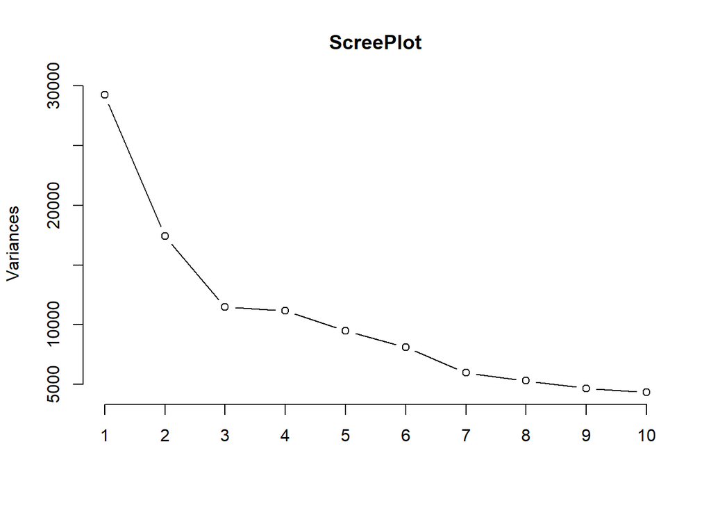

```r
plot(PCA_Analysis, main = "ScreePlot", type = "l")
abline(h=2500, col="red")
```